# Another illustration of Matthew’s “proxy SNP” idea on GTEx data set

Peter Carbonetto

October 26, 2017

## Outline

In this example, we consider fine-mapping for a slightly more complicated scenario in which multiple SNPs are independently associated with a (gene expression) quantitative trait within a single locus. Despite the added complexity, the simple fine-mapping scheme seems to work well for this example, although some potential issues could occur in similar examples.

## Set up environment

Load a few packages.

```r
library(ggplot2)
library(cowplot)
library(varbvs)
```

Also, install the varbvs package from the “finemap” branch on Github.

```r
library(devtools)
install_github("pcarbo/varbvs",ref = "finemap",subdir = "varbvs-R")
```

## Script parameters

The causal variant should be within the credible set with this probability.

```r
credint.prob <- 0.95
```

For identifying the credible set, compute proxy probabilities for all SNPs in LD with the target SNP based on this threshold.

```r
ld.threshold <- 0.2
```

## Load genotype data

Retrieve genotype data for 1,000 SNPs near gene *FMO2*.

```r
load("../datafiles/Thyroid.FMO2.1Mb.RData")
storage.mode(X) <- "double"
X <- X[,3501:4500]
n <- nrow(X)
p <- ncol(X)
```

## Fit variational approximation to posterior

Fit the fully-factorized variational approximation to the posterior distribution of the coefficients for a linear regression model of a continuous outcome (quantitiative trait), with spike and slab priors on the coefficients. We find that multiple SNPs in this locus are independently associated with gene expression, even when the prior is very conservative (that is, 1 SNP is associated with the gene expression trait *a priori*).

```r
set.seed(1)
fit <- varbvs(X,Z,y,verbose = FALSE)
sum(fit$alpha[,1] > 0.95)
# [1] 4
```

## Compute proxy probabilities

This function computes the “probability probabilities” assuming that exactly 1 SNP is causal, then selects the smallest set of SNPs such that the sum of the proxy probabilities is greater than “pr”.

```r
get.credible.set <- function (bf, pr) {
  pp      <- bf/sum(bf)
  markers <- order(bf,decreasing = TRUE)
  n       <- min(which(cumsum(pp[markers]) > credint.prob))
  return(markers[1:n])
}
```

## Plot fine-mapping results

To plot the fine-mapping results, I highlight the credible SNP sets in green, and otherwise points are coloured according to LD with each of the top SNPs.

```r
create.finemap.plot <- function (pip, r, markers, plot.title = NULL) {
  clrs <- c("midnightblue","darkviolet","darkorchid","maroon",
            "tomato","orange","gold","yellow")
  dat <- data.frame(pos = 1:p,pip = fit$pip,r = r)
  return(ggplot(mapping = aes(x = pos,y = pip,color = r),
                environment = environment()) +
    geom_point(data = dat,size = 2,shape = 20) +
    geom_point(data = dat[markers,],color = "limegreen",
               shape = 20,size = 2) +
    scale_x_continuous(breaks = NULL) +
    scale_y_continuous(trans = "log10",breaks = 10^(-4:0)) +
    scale_color_gradientn(colors = clrs,guide = FALSE) +
    labs(x = "",y = "varbvs PIP",title = plot.title) +
    theme_cowplot(font_size = 9) +
    theme(axis.line  = element_blank(),
          plot.title = element_text(size = 9,face = "plain")))
}
```

Compute the correlations between all the SNPs.

```r
R <- cor(X)
```

To test the idea of computing credible SNP sets based on “proxy probabilities”, here I choose the top SNPs by posterior inclusion probability (PIP), take all candidate SNPs in LD with each of the top SNPs (based on a pre-specified threshold), then compute the Bayes factors measuring the improvement in “fit” by using alternative SNPs instead of the top SNP.

Get the SNPs with PIP > 0.95.

```r
top.markers <- summary(fit,nv = 20)$top.vars
top.markers <- subset(top.markers,prob > 0.95)$variable
m           <- length(top.markers)
```

Compute the credible SNP sets, taking the strategy as described above. Note that the credible set may not include the top SNP—this could happen because the Bayes factor calculations do not control for the effects of nearby, independently associated SNPs as effectively as the multi-SNP regression analysis (as implemented in `varbvs`).

```r
cr           <- vector("list",m)
plots        <- vector("list",m)
names(cr)    <- top.markers
names(plots) <- top.markers
for (i in top.markers) {
  idx        <- which(colnames(X) == i)
  vars       <- which(R[,i]^2 >= ld.threshold)
  out        <- varbvsproxybf(X,Z,y,fit,idx,vars)
  cr[[i]]    <- vars[get.credible.set(out$BF[,1],credint.prob)]
  j          <- names(which.max(out$BF[,1]))
  plots[[i]] <- create.finemap.plot(fit$pip,abs(R[,j]),cr[[i]],
                                    sprintf("%s (%d)",j,length(cr[[i]])))
}
```

Also note that the Bayes factors are computed separately for each hyperparameter setting. Here, to simplify the example, I’ve taken the Bayes factors from the first hyperparameter setting (corresponding to the smallest prior inclusion probability).

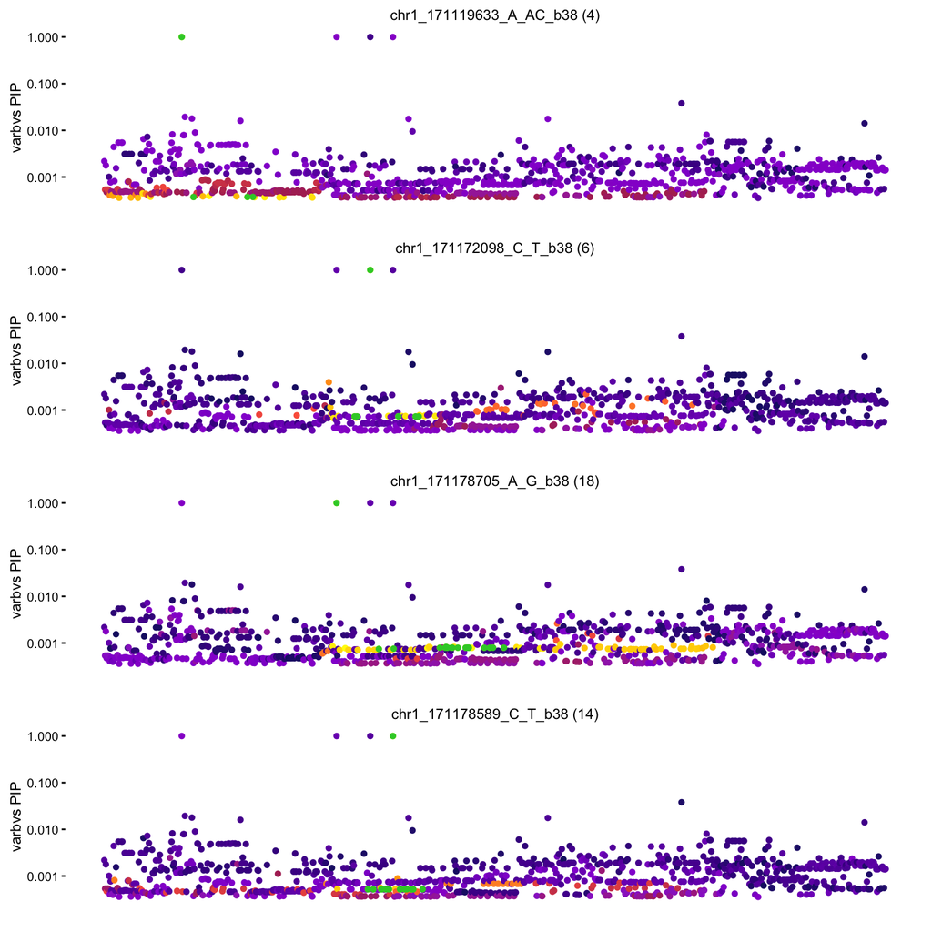

```r
do.call("plot_grid",c(plots,list(nrow = 4,ncol = 1)))
```

In these plots, the number in the parentheses gives the number of SNPs in the credible SNP set.

None of the credible sets overlap, so in this particular example it is safe to treat the independent associations as implicating distinct causal variants.

```r
sum(sapply(cr,length))
length(unique(do.call("c",cr)))
# [1] 42
# [1] 42
```

## Session information

This is the computing environment, version of R and packages that were used to generate these results.

```r
sessionInfo()
# R version 3.4.1 (2017-06-30)
# Platform: x86_64-apple-darwin15.6.0 (64-bit)
# Running under: macOS Sierra 10.12.6
#
# Matrix products: default
# BLAS: /Library/Frameworks/R.framework/Versions/3.4/Resources/lib/libRblas.0.dylib
# LAPACK: /Library/Frameworks/R.framework/Versions/3.4/Resources/lib/libRlapack.dylib
#
# locale:
# [1] en_US.UTF-8/en_US.UTF-8/en_US.UTF-8/C/en_US.UTF-8/en_US.UTF-8
#
# attached base packages:
# [1] stats     graphics  grDevices utils     datasets  methods   base
#
# other attached packages:
# [1] rmarkdown_1.6 varbvs_2.4-9  cowplot_0.8.0 ggplot2_2.2.1
#
# loaded via a namespace (and not attached):
#  [1] Rcpp_0.12.12        knitr_1.17          magrittr_1.5
#  [4] munsell_0.4.3       colorspace_1.3-2    lattice_0.20-35
#  [7] rlang_0.1.1         stringr_1.2.0       plyr_1.8.4
# [10] tools_3.4.1         grid_3.4.1          gtable_0.2.0
# [13] latticeExtra_0.6-28 htmltools_0.3.6     yaml_2.1.14
# [16] lazyeval_0.2.0      digest_0.6.12       rprojroot_1.2
# [19] tibble_1.3.3        Matrix_1.2-10       RColorBrewer_1.1-2
# [22] evaluate_0.10.1     labeling_0.3        stringi_1.1.5
# [25] compiler_3.4.1      scales_0.4.1.9002   backports_1.1.0
```